# pitchPrediction

## Results:

Now let's take a look at the transition matrix created by the markov model. This will let us have a granualr look at pitch probabilities given the pitch sequence while factoring in context variables.

First we will start with simple transition probabilities without looking at context.

We will setup plotting code to show the transition matrix.

```python
import numpy as np
import pandas as pd
from collections import Counter, defaultdict
from typing import Optional, Tuple, List, Dict, Any

def _aggregate_hist_counts(
    model,
    k: int = 1,
    use_family: bool = False,
    ctx: Optional[Tuple] = None,
) -> Dict[Tuple, Counter]:

    assert 1 <= k <= model.K, "k must be between 1 and model.K"

    # choose source table
    table = model.counts_fam if use_family else model.counts_type
    bucket = table[k-1]

    agg: Dict[Tuple, Counter] = defaultdict(Counter)

    if ctx is None:
        # sum across all contexts
        for (hist, c), next_cnt in bucket.items():
            agg[hist].update(next_cnt)
    else:
        # filter for the specific context
        for (hist, c), next_cnt in bucket.items():
            if c == ctx:
                agg[hist].update(next_cnt)

    return agg

def _normalize_rows_to_probs(
    row_counters: Dict[Tuple, Counter],
    vocab: List[str],
    alpha: float = 1.0,
    min_count: int = 0
) -> pd.DataFrame:

    rows = []
    index = []
    V = len(vocab)
    for row_key, cnt in row_counters.items():
        total = sum(cnt.values())
        if total < min_count:
            continue
        denom = total + alpha * V
        row = [ (cnt.get(tok, 0) + alpha) / denom for tok in vocab ]
        rows.append(row)
        index.append(row_key)

    if not rows:
        return pd.DataFrame(columns=vocab)

    df = pd.DataFrame(rows, index=index, columns=vocab)
    return df

def make_transition_matrix(
    model,
    k: int = 1,
    use_family: bool = False,
    ctx: Optional[Tuple] = None,
    alpha: Optional[float] = None,
    min_row_count: int = 0,
    top_n_rows: Optional[int] = None,
) -> pd.DataFrame:

    if alpha is None:
        alpha = model.alpha

    row_counters = _aggregate_hist_counts(model, k=k, use_family=use_family, ctx=ctx)

    # Optionally keep only top-N rows by mass
    if top_n_rows is not None and top_n_rows > 0 and len(row_counters) > top_n_rows:
        # compute totals
        totals = {h: sum(c.values()) for h, c in row_counters.items()}
        keep = set(sorted(totals, key=totals.get, reverse=True)[:top_n_rows])
        row_counters = {h: c for h, c in row_counters.items() if h in keep}

    mat = _normalize_rows_to_probs(
        row_counters=row_counters,
        vocab=model.vocab,
        alpha=alpha,
        min_count=min_row_count
    )

    # give friendly row labels
    def fmt_hist(h):
        return " | ".join(map(str, h))
    mat.index = [fmt_hist(h) for h in mat.index]
    return mat
import numpy as np
import pandas as pd
from collections import Counter, defaultdict
from typing import Optional, Tuple, List, Dict, Any

def _aggregate_hist_counts(
    model,
    k: int = 1,
    use_family: bool = False,
    ctx: Optional[Tuple] = None,
) -> Dict[Tuple, Counter]:

    assert 1 <= k <= model.K, "k must be between 1 and model.K"

    # choose source table
    table = model.counts_fam if use_family else model.counts_type
    bucket = table[k-1]

    agg: Dict[Tuple, Counter] = defaultdict(Counter)

    if ctx is None:
        # sum across all contexts
        for (hist, c), next_cnt in bucket.items():
            agg[hist].update(next_cnt)
    else:
        # filter for the specific context
        for (hist, c), next_cnt in bucket.items():
            if c == ctx:
                agg[hist].update(next_cnt)

    return agg

def _normalize_rows_to_probs(
    row_counters: Dict[Tuple, Counter],
    vocab: List[str],
    alpha: float = 1.0,
    min_count: int = 0
) -> pd.DataFrame:

    rows = []
    index = []
    V = len(vocab)
    for row_key, cnt in row_counters.items():
        total = sum(cnt.values())
        if total < min_count:
            continue
        denom = total + alpha * V
        row = [ (cnt.get(tok, 0) + alpha) / denom for tok in vocab ]
        rows.append(row)
        index.append(row_key)

    if not rows:
        return pd.DataFrame(columns=vocab)

    df = pd.DataFrame(rows, index=index, columns=vocab)
    return df

def make_transition_matrix(
    model,
    k: int = 1,
    use_family: bool = False,
    ctx: Optional[Tuple] = None,
    alpha: Optional[float] = None,
    min_row_count: int = 0,
    top_n_rows: Optional[int] = None,
) -> pd.DataFrame:

    if alpha is None:
        alpha = model.alpha

    row_counters = _aggregate_hist_counts(model, k=k, use_family=use_family, ctx=ctx)

    # Optionally keep only top-N rows by mass
    if top_n_rows is not None and top_n_rows > 0 and len(row_counters) > top_n_rows:
        # compute totals
        totals = {h: sum(c.values()) for h, c in row_counters.items()}
        keep = set(sorted(totals, key=totals.get, reverse=True)[:top_n_rows])
        row_counters = {h: c for h, c in row_counters.items() if h in keep}

    mat = _normalize_rows_to_probs(
        row_counters=row_counters,
        vocab=model.vocab,
        alpha=alpha,
        min_count=min_row_count
    )

    # give friendly row labels
    def fmt_hist(h):
        return " | ".join(map(str, h))
    mat.index = [fmt_hist(h) for h in mat.index]
    return mat
```

```python
import numpy as np
import pandas as pd
import matplotlib.pyplot as plt


from scipy.spatial.distance import pdist, squareform
from scipy.cluster.hierarchy import linkage, leaves_list

def clustered_order(df: pd.DataFrame, axis=0, metric="cosine", method="average"):
    """
    Returns an index order obtained by hierarchical clustering along rows (axis=0) or columns (axis=1).
    """
    X = df.values if axis == 0 else df.values.T
    # If any rows are constant zero, add tiny epsilon to avoid NaNs in distance
    eps = 1e-12
    X = X + eps
    # Distances & linkage
    D = pdist(X, metric=metric)
    Z = linkage(D, method=method)
    order = leaves_list(Z)
    if axis == 0:
        return list(df.index[order])
    else:
        return list(df.columns[order])

def plot_heatmap(df: pd.DataFrame,
                        title: str = "",
                        annotate_threshold: float = 0.20,
                        figsize=(11, 8)):
    """
    Cluster rows to group similar transition profiles, annotate only large probabilities.
    """
    if df.empty:
        raise ValueError("Empty matrix: nothing to plot")

    # Row clustering (keeps columns in the original order for familiarity)
    row_order = clustered_order(df, axis=0, metric="cosine", method="average")
    df_ord = df.loc[row_order]

    # Optional column clustering:
    # col_order = clustered_order(df, axis=1, metric="cosine", method="average")
    # df_ord = df_ord[col_order]

    fig, ax = plt.subplots(figsize=figsize)
    im = ax.imshow(df_ord.values, aspect="auto")

    # ticks
    ax.set_yticks(range(len(df_ord.index)))
    ax.set_yticklabels(df_ord.index, fontsize=8)
    ax.set_xticks(range(len(df_ord.columns)))
    ax.set_xticklabels(df_ord.columns, rotation=45, ha="right", fontsize=8)

    ax.set_xlabel("Next pitch type")
    ax.set_ylabel("History")
    ax.set_title(title)

    # annotate only salient probs
    m, n = df_ord.shape
    if m * n <= 3000:
        for i in range(m):
            for j in range(n):
                v = df_ord.iat[i, j]
                if v >= annotate_threshold:
                    ax.text(j, i, f"{v:.2f}", ha="center", va="center", fontsize=6)

    cbar = plt.colorbar(im, ax=ax, fraction=0.046, pad=0.04)
    cbar.ax.set_ylabel("P(next | history)", rotation=270, labelpad=12)
    plt.tight_layout()
    plt.show()
```

Now let's plot out transition matrixies for varying context windows 1,2,3.

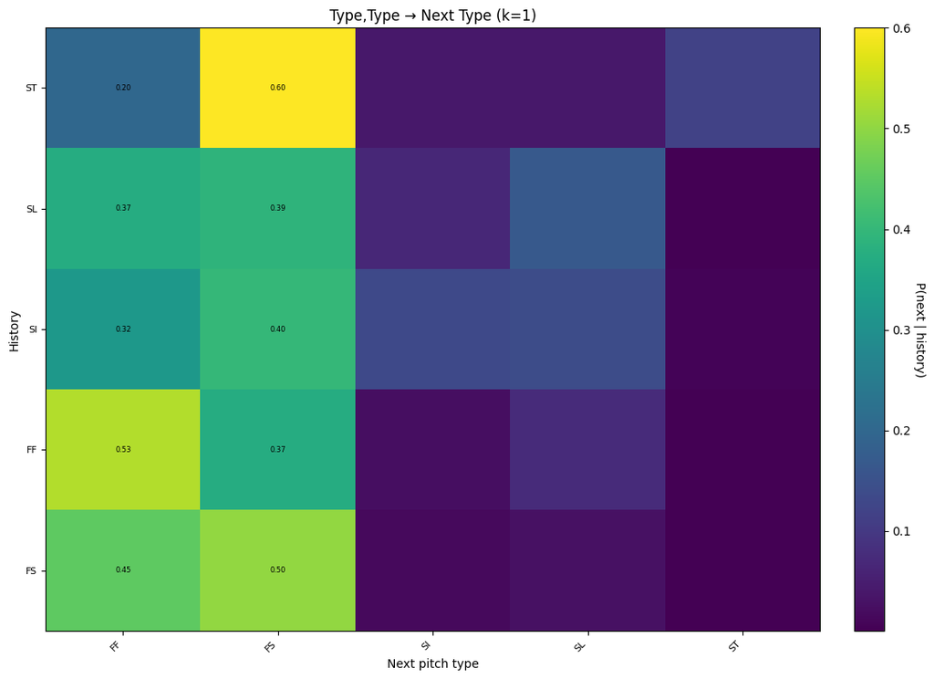

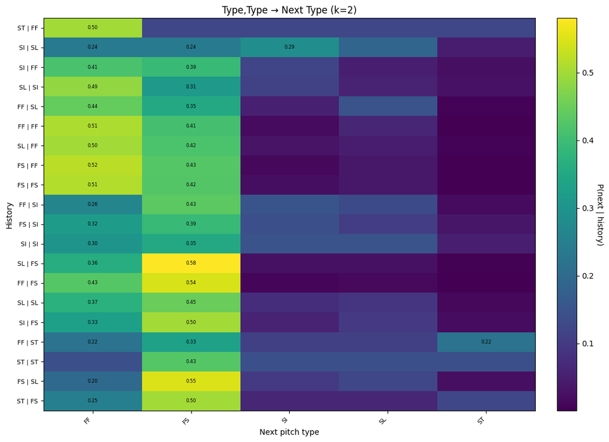

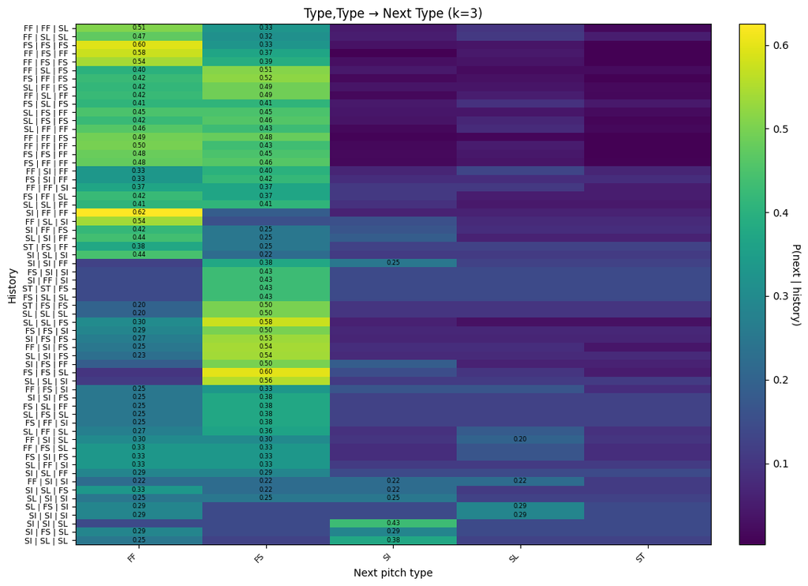

```python
for context in range(1,4):
    mat_k2 = make_transition_matrix(model, k=context, use_family=True, ctx=None, min_row_count=2, top_n_rows=1000)
    plot_heatmap(mat_k2, title=f"Type,Type → Next Type (k={context})")
```

## Adding in Context

Let's extend that to consider the pitcher matchup context values. Considering LR, and RR matchups, (Right handed pitcher).

```
Heatmaps for k=1
```

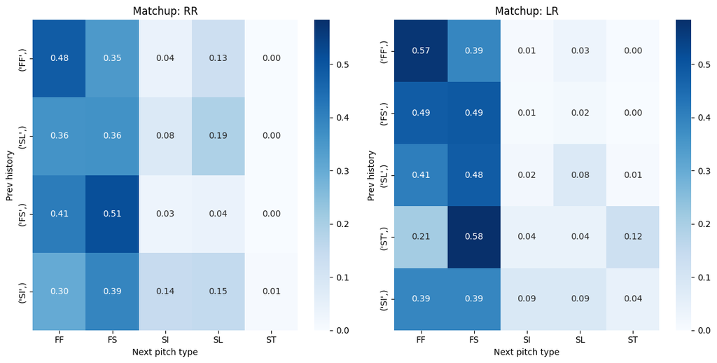

```
Heatmaps for k=2
```

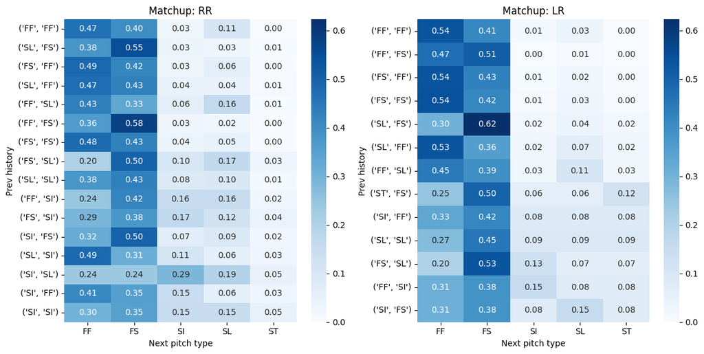

```
Heatmaps for k=3
```

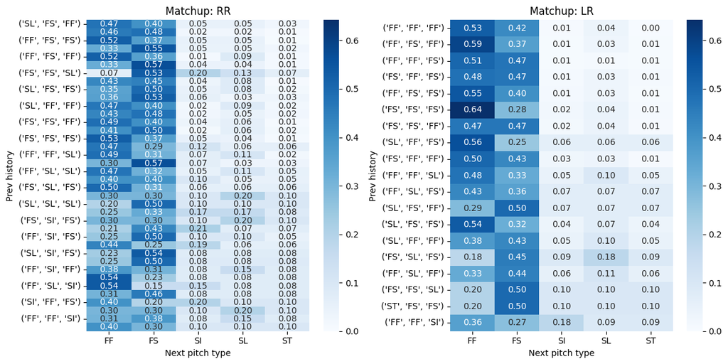

```python
import matplotlib.pyplot as plt
import seaborn as sns
import numpy as np
import pandas as pd
from collections import Counter

def plot_transition_heatmaps_grid(model, matchups=("RR","LR"),
                                  k=1, min_row_count=5,
                                  figsize=(12,6), cmap="Blues"):
    """
    Plot a grid of transition heatmaps, one subplot per matchup.

    Args:
      model: trained ContextualOrderKMarkov
      matchups: tuple of matchup strings to plot, e.g. ("RR","LR")
      k: order of history (default 1 = bigram)
      min_row_count: drop rows with too few counts
      figsize: overall figure size
      cmap: seaborn colormap
    """
    n = len(matchups)
    fig, axes = plt.subplots(1, n, figsize=figsize, squeeze=False)

    # Precompute matrices for each matchup
    mats = {}
    for m in matchups:
        row_counters = {}
        for (hist, ctx), cnt in model.counts_type[k-1].items():
            if ctx[0] == m:   # ctx[0] is the matchup
                row_counters.setdefault(hist, Counter()).update(cnt)
        if row_counters:
            mat = _normalize_rows_to_probs(row_counters,
                                           vocab=model.vocab,
                                           alpha=model.alpha,
                                           min_count=min_row_count)
            mats[m] = mat
        else:
            mats[m] = pd.DataFrame(columns=model.vocab)

    # shared color scale for comparability
    all_vals = [mat.values.flatten() for mat in mats.values() if not mat.empty]
    vmin, vmax = (0, 1) if not all_vals else (0, np.max(np.concatenate(all_vals)))

    # plot each subplot
    for ax, m in zip(axes[0], matchups):
        mat = mats[m]
        if mat.empty:
            ax.set_title(f"{m}\n(no data)")
            ax.axis("off")
            continue

        sns.heatmap(mat, annot=True, fmt=".2f",
                    cmap=cmap, vmin=vmin, vmax=vmax,
                    cbar=True, ax=ax)
        ax.set_title(f"Matchup: {m}")
        ax.set_xlabel("Next pitch type")
        ax.set_ylabel("Prev history")

    plt.tight_layout()
    plt.show()

for k in range(1,4):
    print(f"Heatmaps for k={k}")
    plot_transition_heatmaps_grid(model, matchups=("RR","LR"), k=k)
```